# Project Milestone 2

```r
# Overall Averages
baseballdatacleanqual %>%
  ungroup() %>%
  summarize(across(vars, ~mean(. , na.rm = TRUE)))
```

```
# A tibble: 1 × 5
   pfx_x pfx_z release_speed speeddiff release_spin_rate
   <dbl> <dbl>         <dbl>     <dbl>             <dbl>
1 -0.113 0.653          89.6     0.290             2242.
```

```r
# Averages When Hitters Swing SLOWER than their average swing speed
baseballdatacleanqual %>%
  filter(fasterthanavg == FALSE) %>%
  ungroup() %>%
  summarize(across(vars, ~mean(. , na.rm = TRUE)))
```

```
# A tibble: 1 × 5
   pfx_x pfx_z release_speed speeddiff release_spin_rate
   <dbl> <dbl>         <dbl>     <dbl>             <dbl>
1 -0.108 0.660          89.7     0.288             2253.
```

```r
# Averages When Hitters Swing FASTER than their average swing speed
baseballdatacleanqual %>%
  filter(fasterthanavg == TRUE) %>%
  ungroup() %>%
  summarize(across(vars, ~mean(. , na.rm = TRUE)))
```

```
# A tibble: 1 × 5
   pfx_x pfx_z release_speed speeddiff release_spin_rate
   <dbl> <dbl>         <dbl>     <dbl>             <dbl>
1 -0.117 0.647          89.5     0.292             2234.
```

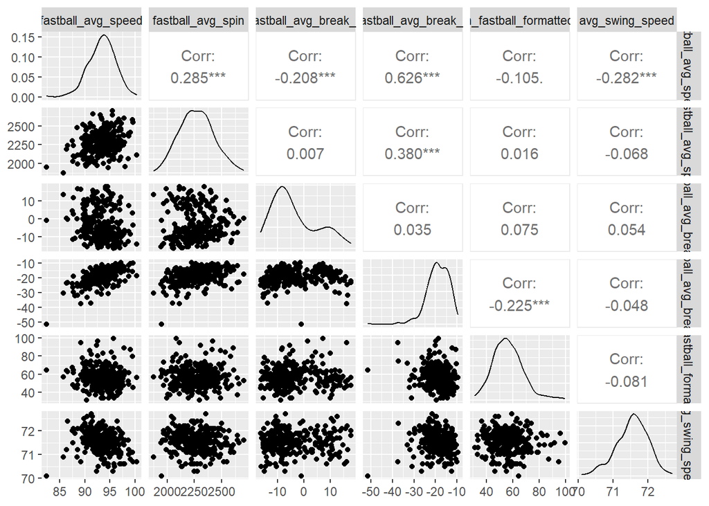

```r
library(GGally)
ggpairs(pitcherdata, columns = c("fastball_avg_speed", "fastball_avg_spin", "fastball_avg_break_x", "fastball_avg_break_z","n_fastball_formatted", "avg_swing_speed"))
```

```r
slowerpitchcount <- baseballdatacleanqual %>%
  filter(fasterthanavg == FALSE) %>%
  ungroup() %>%
  group_by(pitch_name) %>%
  summarize(slowerbatspeed = n())

totalpitchcount <- baseballdatacleanqual %>%
  ungroup() %>%
  group_by(pitch_name) %>%
  summarize(totalpitches = n())

slowerpitchcount %>%
  full_join(totalpitchcount) %>%
  filter(pitch_name != "Forkball" & pitch_name != "Knuckleball" & pitch_name != "Slurve" & pitch_name != "Slow Curve") %>%
  mutate(propslowerbat = slowerbatspeed / totalpitches) %>%
  arrange(desc(propslowerbat))
```

```
# A tibble: 9 × 4
  pitch_name slowerbatspeed totalpitches propslowerbat
  <chr>               <int>        <int>         <dbl>
1 4 Seam              15446        34043         0.454
2 Sweeper              2235         4977         0.449
3 K Curve               589         1338         0.440
4 Curveball            2279         5240         0.435
5 Slider               6047        14265         0.424
6 Splitter             1290         3157         0.409
7 Sinker               6828        17272         0.395
8 Changeup             3920        10218         0.384
9 Cutter               3105         8557         0.363
```

# Data Context

Our data was collected using Statcast, by CSAS (Connecticut Sports Analytics) to analyze pitcher-batter interactions in MLB. Every MLB ballpark is equipped with Statcast tracking technology, which is used to acquire the data. See this link [statcastlink](https://www.mlb.com/glossary/statcast) for more background on Statcast. It contains data on 346,250 Major League Baseball plate appearances from 4/2/2024 to 6/30/2024 (first half of the 2024 regular season), as well as 94 different variables.

Link to player ID data: [playerdatalink](https://www.smartfantasybaseball.com/tools/)

## Data Codebook

The codebook for our data can be found at this link: [codebooklink](https://baseballsavant.mlb.com/csv-docs)

# Project Topic

The effect of pitchers on batters’ swing speeds and swing lengths

# Questions We Wish To Explore

1. Do pitchers modify batters’ behavior? That is do batters’ swing speeds differ depending on something pitchers do?
2. Do some pitchers elicit different swing speeds and swing lengths than others? That is, are some pitchers better at slowing down batters’ swing speeds or making their swings longer?
3. If pitchers do affect a batter’s swing speed/length, what is the cause of this? Is it pitch speed, pitch movement, or something else?

# Plan to Further Explore Questions

We plan to improve the visualizations we have already created, as well as create more visualizations that explore the batter/pitcher interaction. We found another dataset as suggested in our Milestone 1 Feedback, and we would like to better integrate this additional dataset into our analysis. We would also like to have a concrete answer to our third broad question, and begin interpreting our results.

# Create new variable indicating whether a players bat speed was slower or faster than their average, and then use it for analyis like above